# Unit 2 Exercise 08

## Birth Weights and Tobacco Use During Pregnancy

Are babies’ birth weights affected by whether or not the mother used tobacco during pregnancy? Low birth weights are a risk factor for health problems later in life, so this is important!

Here is a data set with data on a sample of randomly selected babies who were born in North Carolina in 2004, with some information about the mother and the babies’ weights in grams:

```r
head(NCBirths2004)
```

```
##   ID MothersAge Tobacco Alcohol Gender Weight Gestation
## 1  1      30-34      No      No   Male   3827        40
## 2  2      30-34      No      No   Male   3629        38
## 3  3      35-39      No      No Female   3062        37
## 4  4      20-24      No      No Female   3430        39
## 5  5      25-29      No      No   Male   3827        38
## 6  6      35-39      No      No Female   3119        39
```

### Warm up

Please use the provided .Rmd template to complete the following problems. To download this template, copy the following code in the Rstudio console and hit enter:

```r
download.file("https://raw.githubusercontent.com/sshanshans/stat140/master/docs/labs/u2d4/08Exercise.Rmd", destfile = "Ex08.Rmd")
```

1. What’s the observational units in this data? We are inerested two variables `Weight` and `Tobacco`. What kind of variables are they? Write your answer below

### Plotting the data

Plotting is always fun!

#### I. Box plot

Here is a side-by-side box plot

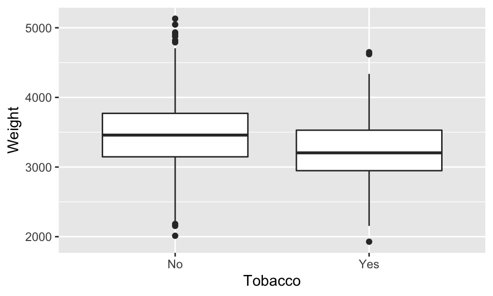

2. What is the code that makes the plot looks like above? Hint:

```r
ggplot(data = ____, mapping = aes(x = ____, y = ____)) +
  geom_boxplot()
```

#### II. Colored histogram

Here’s a colored histogram plot of the data:

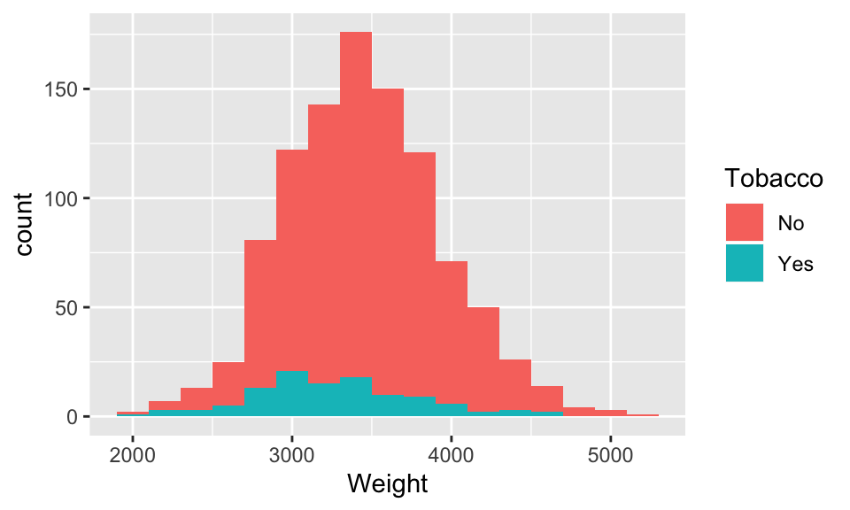

3. What is the code that makes the plot looks like above? Hint:

```r
ggplot(data = ____, mapping = aes(x = ____, fill = ____)) +
  geom_histogram(binwidth = 200)
```

#### III. Density plot

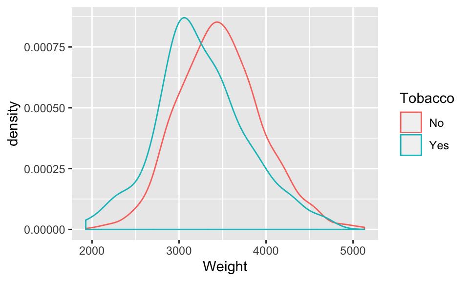

4. What is the code that makes the plot looks like above? Hint:

```r
ggplot(data = ____, mapping = aes(x = ____, color = ____)) +
  geom_density()
```

#### IV. Title and label axes

The labels on the x- and y- axis are not very informative so far. Let’s change the x-axis label to “Baby’s weight” and the y-axis to “Density”. Furthermore, let’s change the legend label to “Mother’s tobacco usage”. To do this, add `labs( )` to the existing ggplot layers and specify each axis you’d like to label as arguments, e.g. `x =`, followed by the string for your label. If you’d like to learn more about manipulations you can do with `labs( )`, see [this reference](https://ggplot2.tidyverse.org/reference/labs.html).

5. Add the following code to your answer to Exercise 4 to modify the labels.

```r
 labs(x="Baby's weight", y="Density", color="Mother's tobacco usage")
```

In addition, we can also include a title by adding `ggtitle()` to the existing ggplot layers.

6. Add the following code to your answer to Exercise 5 to modify the title.

```r
ggtitle("Density plot of baby's weight over mother's tobacco usage.")
```

### Facet: create multiple copies of the same type of plot

Faceting is used when we’d like to split a particular visualization by the values of another variable. This will create multiple copies of the same type of plot with matching x and y axes, but whose content will differ.

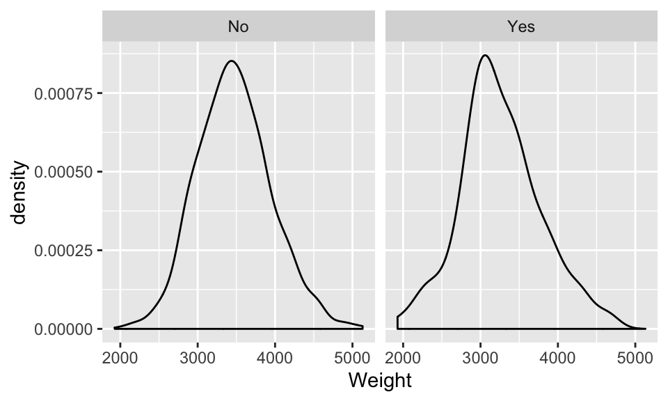

5. What is the code that makes the plot looks like above?

```r
ggplot(data = _____, mapping = aes(x = _____)) +
   geom_density() +
   facet_wrap(~ ____)
```

### Summaries of numerical variables across groups

#### I. function `group_by`

If we wanted to just calculate these summaries for all babies combined (across both groups), we would write the following code.

```r
NCBirths2004 %>%
  summarize(
    mean_wt = mean(Weight),
    median_wt = median(Weight),
    q1_wt = quantile(Weight, probs = 0.25),
    q3_wt = quantile(Weight, probs = 0.75),
    iqr_wt = IQR(Weight),
    var_wt = var(Weight),
    sd_wt = sd(Weight)
  )
```

6. We saw from the plot that there seems to be a difference in birth weights. What are “typical” birth weights for the two groups? Let’s use the `group_by` function.

```r
NCBirths2004 %>%
  group_by(____) %>%
  summarize(
    _______
  )
```

#### II. Sorting the data: `arrange`

What was the shortest gestation time?

To answer this question, we will `arrange` the babies in increasing order of gestation time. Then, the babies with the shortest gestation times will be near the `head` of the data frame.

```r
NCBirths_by_gestation <- NCBirths2004 %>%
  arrange(Gestation)

head(NCBirths_by_gestation)
```

```
##   ID MothersAge Tobacco Alcohol Gender Weight Gestation
## 1  3      35-39      No      No Female   3062        37
## 2 15      30-34      No      No   Male   3232        37
## 3 20      25-29      No      No   Male   3005        37
## 4 29      15-19      No      No Female   2863        37
## 5 31      20-24      No      No   Male   2155        37
## 6 32      20-24     Yes      No Female   3062        37
```

7. What was the longest gestation time? Now we want to `arrange` the babies in `desc`ending order of gestation time, so the longest gestation times will be at the `head` of the data frame.

#### III. Modifying or Adding a Variable: `mutate`

The babies’ birth `Weights` are currently recorded in grams. Let’s add a new variable to the data frame called `Weight_lbs` with the babies’ birth weights in pounds.

There are about 453.6 grams in a pound. We can divide the weight in grams by 453.6 to get the weight in pounds.

8. Modify the following code to complete the task.

```r
NCBirths2004 <- NCBirths2004 %>%
  mutate(
    Weight_lbs = ________
  )
head(NCBirths2004)
```

### Customize your ggplot (optional)

#### I. Customize color

Colors in R can be specified in different ways. For example, you can use a string of the color name (see possible colors [here](http://sape.inf.usi.ch/quick-reference/ggplot2/colour)) or with [hex color codes](https://htmlcolorcodes.com).

9. Add the following code to your answer in Exercise 6 to change the color scheme

```r
scale_color_manual(values = c("green3", "turquoise3"))
```

#### II. Remove minor grid lines

To make detailed changes to the layout, we can add a `theme( )` argument. Nested within `theme( )` we can use additional arguments, such as `panel.grid.minor=`. Many `theme( )` arguments can be set to `element_blank( )` to remove the element in question. To read more about what can be modifed with `theme( )`, check out [this resource](https://ggplot2.tidyverse.org/reference/theme.html).

10. Add the following code to your answer in Exercise 6 to remove the minor grid lines

```r
theme(panel.grid.minor=element_blank())
```